# Climate analysis Las Cruces

Helene Wagner

Code adapted from: https://www.earthdatascience.org/courses/earth-analytics/time-series-data/summarize-time-series-by-month-in-r/

## 1. Preparations

Load packages

```r
library(ggplot2)
library(dplyr)
library(lubridate)
library(zoo)
library(tidyr)
```

Set strings as factors to false

```r
options(stringsAsFactors = FALSE)
```

## 2. Import data

```r
Filenames.xlsx <- list.files(paste0(here::here(), "/data"), pattern="xlsx")
n.complete <- rep(c(24*2, 24*4), times=c(17,15))  # Number of records per complete day
```

List with one table per data file

```r
Data <- list()
for(f in 1:length(Filenames.xlsx))
{
  data <- readxl::read_excel(paste0(here::here(), "/data/", Filenames.xlsx[f]),
         skip=3)[,c(1,2,3,5,7,8)]
  names(data) <- c("Date", "Temperature", "TempMax", "TempMin", "Humidity", "Rainfall")
  data$Date <- as.POSIXct(data$Date, format = "%m/%d/%Y %H:%M", tz="America/Costa_Rica")
  data$day <- as.Date(data$Date, format="%Y-%m-%d")
  data$n.complete <- n.complete[f]
  Data[[f]] <- data
}
```

Combine all data into a single table

```r
Data <- Reduce(rbind,Data)
head(Data)
```

```
## # A tibble: 6 x 8
##   Date                Temperature TempMax TempMin Humidity Rainfall day
##   <dttm>                    <dbl>   <dbl>   <dbl>    <dbl>    <dbl> <date>
## 1 2008-12-31 23:30:00        16.8    16.9    16.5     96.7        0 2009-01-01
## 2 2008-12-31 23:00:00        17.1    17.2    16.8     97.1        0 2009-01-01
## 3 2008-12-31 22:30:00        17.2    17.3    17.0     97.1        0 2009-01-01
## 4 2008-12-31 22:00:00        17.1    17.3    17.0     97.2        0 2009-01-01
## 5 2008-12-31 21:30:00        17.1    17.2    17.0     96.9        0 2009-01-01
## 6 2008-12-31 21:00:00        16.9    17.0    16.8     96.5        0 2009-01-01
## # … with 1 more variable: n.complete <dbl>
```

## 3. Quality control

Check range of variables

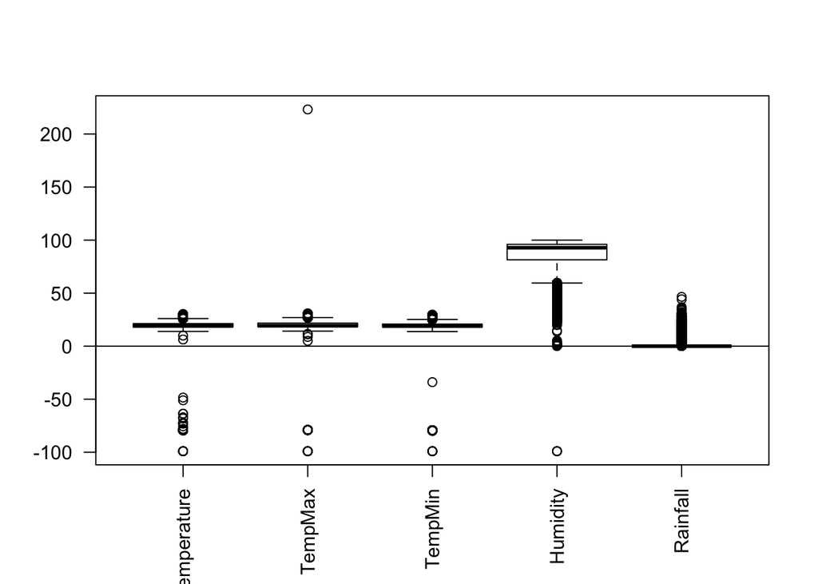

```r
boxplot(Data[,2:6], las=2)
lines(c(0,15), c(0,0))
```

List unusual values

```r
Data %>% filter(TempMax > 40)
```

```
## # A tibble: 1 x 8
##   Date                Temperature TempMax TempMin Humidity Rainfall day
##   <dttm>                    <dbl>   <dbl>   <dbl>    <dbl>    <dbl> <date>
## 1 2014-06-11 11:30:00        22.7    223.    22.3     82.3        0 2014-06-11
## # … with 1 more variable: n.complete <dbl>
```

```r
Data %>% filter(TempMax < 0)
```

```
## # A tibble: 139 x 8
##    Date                Temperature TempMax TempMin Humidity Rainfall day
##    <dttm>                    <dbl>   <dbl>   <dbl>    <dbl>    <dbl> <date>
##  1 2016-03-03 11:30:00       -99     -99     -99      51.5     0     2016-03-03
##  2 2016-03-03 11:00:00       -99     -99     -99     -99       0     2016-03-03
##  3 2016-03-03 10:30:00       -99     -99     -99     -99       0     2016-03-03
##  4 2016-03-03 10:00:00       -99     -99     -99     -99       0     2016-03-03
##  5 2016-03-03 09:30:00       -99     -99     -99     -99       0     2016-03-03
##  6 2016-03-03 09:00:00       -99     -99     -99      29.8     0     2016-03-03
##  7 2017-12-04 14:30:00       -79.2   -79.0   -79.3     0.54    0     2017-12-04
##  8 2017-12-04 14:00:00       -79.2   -79.0   -79.3     0.53    0.254 2017-12-04
##  9 2017-12-04 13:45:00       -79.2   -79.0   -79.3     0.53    0     2017-12-04
## 10 2017-12-04 13:30:00       -79.2   -79.0   -79.3     0.53    0     2017-12-04
## # … with 129 more rows, and 1 more variable: n.complete <dbl>
```

```r
Data %>% filter(Temperature < 0)
```

```
## # A tibble: 154 x 8
##    Date                Temperature TempMax TempMin Humidity Rainfall day
##    <dttm>                    <dbl>   <dbl>   <dbl>    <dbl>    <dbl> <date>
##  1 2016-03-03 11:30:00       -99     -99     -99      51.5     0     2016-03-03
##  2 2016-03-03 11:00:00       -99     -99     -99     -99       0     2016-03-03
##  3 2016-03-03 10:30:00       -99     -99     -99     -99       0     2016-03-03
##  4 2016-03-03 10:00:00       -99     -99     -99     -99       0     2016-03-03
##  5 2016-03-03 09:30:00       -99     -99     -99     -99       0     2016-03-03
##  6 2016-03-03 09:00:00       -99     -99     -99      29.8     0     2016-03-03
##  7 2017-12-04 14:30:00       -79.2   -79.0   -79.3     0.54    0     2017-12-04
##  8 2017-12-04 14:00:00       -79.2   -79.0   -79.3     0.53    0.254 2017-12-04
##  9 2017-12-04 13:45:00       -79.2   -79.0   -79.3     0.53    0     2017-12-04
## 10 2017-12-04 13:30:00       -79.2   -79.0   -79.3     0.53    0     2017-12-04
## # … with 144 more rows, and 1 more variable: n.complete <dbl>
```

```r
Data %>% filter(TempMin < 0)
```

```
## # A tibble: 159 x 8
##    Date                Temperature TempMax TempMin Humidity Rainfall day
##    <dttm>                    <dbl>   <dbl>   <dbl>    <dbl>    <dbl> <date>
##  1 2016-03-03 11:30:00       -99     -99     -99      51.5     0     2016-03-03
##  2 2016-03-03 11:00:00       -99     -99     -99     -99       0     2016-03-03
##  3 2016-03-03 10:30:00       -99     -99     -99     -99       0     2016-03-03
##  4 2016-03-03 10:00:00       -99     -99     -99     -99       0     2016-03-03
##  5 2016-03-03 09:30:00       -99     -99     -99     -99       0     2016-03-03
##  6 2016-03-03 09:00:00       -99     -99     -99      29.8     0     2016-03-03
##  7 2017-06-08 17:00:00        17.6    18.3   -79.4    98.5     1.02  2017-06-08
##  8 2017-12-04 14:30:00       -79.2   -79.0   -79.3     0.54    0     2017-12-04
##  9 2017-12-04 14:00:00       -79.2   -79.0   -79.3     0.53    0.254 2017-12-04
## 10 2017-12-04 13:45:00       -79.2   -79.0   -79.3     0.53    0     2017-12-04
## # … with 149 more rows, and 1 more variable: n.complete <dbl>
```

```r
Data %>% filter(Humidity < 0)
```

```
## # A tibble: 4 x 8
##   Date                Temperature TempMax TempMin Humidity Rainfall day
##   <dttm>                    <dbl>   <dbl>   <dbl>    <dbl>    <dbl> <date>
## 1 2016-03-03 11:00:00         -99     -99     -99      -99        0 2016-03-03
## 2 2016-03-03 10:30:00         -99     -99     -99      -99        0 2016-03-03
## 3 2016-03-03 10:00:00         -99     -99     -99      -99        0 2016-03-03
## 4 2016-03-03 09:30:00         -99     -99     -99      -99        0 2016-03-03
## # … with 1 more variable: n.complete <dbl>
```

Set unusual values to NA

```r
Data <- Data %>%
  mutate(Temperature = replace(Temperature, which(Temperature<0), NA)) %>%
  mutate(TempMax = replace(TempMax, which(TempMax<0), NA)) %>%
  mutate(TempMin = replace(TempMin, which(TempMin<0), NA)) %>%
  mutate(Humidity = replace(Humidity, which(Humidity<1), NA)) %>%
  mutate(TempMax = replace(TempMax, which(TempMax>40), NA))
Data <- Data %>%
  mutate(Temperature = replace(Temperature, which(is.na(TempMin)), NA)) %>%
  mutate(TempMax = replace(TempMax, which(is.na(TempMin)), NA)) %>%
  mutate(Humidity = replace(Humidity, which(is.na(TempMin)), NA))
```

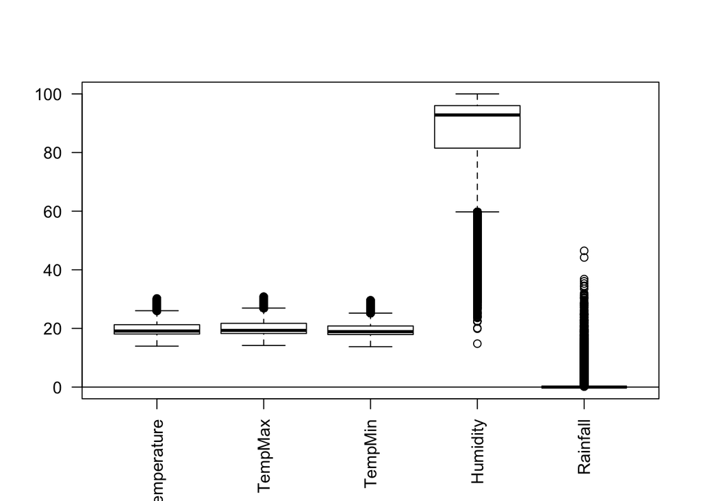

```r
boxplot(Data[,2:6], las=2)
lines(c(0,15), c(0,0))
```

Indicate records with NA values

```r
Data$complete <- apply(is.na(Data), 1, sum) == 0
```

## 4. Assemble daily data

### a) Aggregate by day

Notes:

- n: number of records per day
- mising: number of records with missing values per day
- n.complete: expected number of records per day (depends on recording interval: 30 min or 15 min)
- incomplete: indicator whether daily records are complete (TRUE/FALSE)

```r
daily_data <- Data %>%
  group_by(day) %>% # group by the day column
  summarise(n=n(),
            missing=sum(complete==FALSE),
            n.complete=mean(n.complete),
            total_precip=sum(Rainfall, na.rm=TRUE),
            mean_temp=mean(Temperature, na.rm=TRUE),
            max_temp = max(TempMax, na.rm=TRUE),
            min_temp = min(TempMin, na.rm=TRUE),
            mean_humid=mean(Humidity, na.rm=TRUE),
            min_humid=min(Humidity, na.rm=TRUE))
# %>%  na.omit()  #This would drip rows with incomplete records!

daily_data <- daily_data %>%
  mutate(month = month(day), year=year(day), quarter=zoo::as.yearqtr(day))

daily_data = daily_data %>% mutate(incomplete = ((n - missing) < n.complete))

head(daily_data)
```

```
## # A tibble: 6 x 14
##   day            n missing n.complete total_precip mean_temp max_temp min_temp
##   <date>     <int>   <int>      <dbl>        <dbl>     <dbl>    <dbl>    <dbl>
## 1 2008-08-01     2       0         48         5.59      19.5     19.9     18.9
## 2 2008-08-02    35       0         48        42.4       18.4     21.7     17.4
## 3 2008-08-03    37       0         48        31.5       17.9     22.2     16.5
## 4 2008-08-04    37       0         48         2.54      18.3     22.5     16.8
## 5 2008-08-05    40       0         48         6.10      18.9     22.6     17.0
## 6 2008-08-06    34       0         48        20.8       18.5     21.4     17.3
## # … with 6 more variables: mean_humid <dbl>, min_humid <dbl>, month <dbl>,
## #   year <dbl>, quarter <yearqtr>, incomplete <lgl>
```

### b) Filter for Oct 2008 - Sept 2020

```r
daily_data = daily_data %>% filter(quarter > "2008 Q3" & quarter < "2020 Q4")
```

### c) Check range of variables

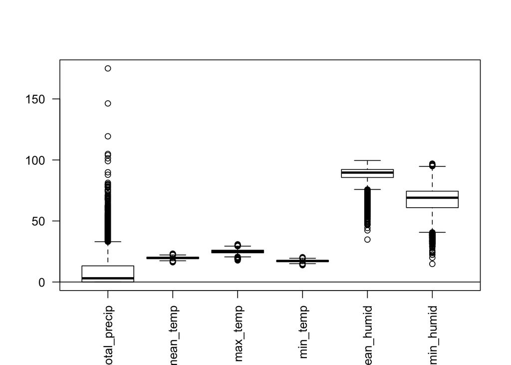

```r
boxplot(daily_data[,5:10], las=2)
lines(c(0,15), c(0,0))
```

## 5. Aggregate by month or quarter

Notes:

- n: number of days with records
- n.incomplete: number of days with incomplete records

### a) Aggregate by month

```r
monthly_data <- daily_data %>%
  group_by(year, month) %>% # group by the month column
  summarise(n=n(),n.incomplete = sum(incomplete),
            total_precip=sum(total_precip),
            mean_temp=mean(mean_temp),
            mean_max_temp = mean(max_temp),
            mean_min_temp = mean(min_temp),
            mean_humid=mean(mean_humid),
            mean_min_humid=min(min_humid))

head(monthly_data)
```

```
## # A tibble: 6 x 10
## # Groups:   year [2]
##    year month     n n.incomplete total_precip mean_temp mean_max_temp
##   <dbl> <dbl> <int>        <int>        <dbl>     <dbl>         <dbl>
## 1  2008    10    31            2       609.        18.9          23.5
## 2  2008    11    30            0       532.        18.8          22.6
## 3  2008    12    31            0       118.        18.8          23.8
## 4  2009     1    31            0        31.5       19.1          24.6
## 5  2009     2    28            0         6.10      19.9          26.4
## 6  2009     3    31            0        85.1       20.2          26.6
## # … with 3 more variables: mean_min_temp <dbl>, mean_humid <dbl>,
## #   mean_min_humid <dbl>
```

### b) Aggregate by quarter (season)

```r
quarterly_data <- daily_data %>%
  group_by(quarter) %>% # group by the quarter column
  summarise(n=n(),n.incomplete = sum(incomplete),
            total_precip=sum(total_precip),
            mean_temp=mean(mean_temp),
            mean_max_temp = mean(max_temp),
            mean_min_temp = mean(min_temp),
            mean_humid=mean(mean_humid),
            mean_min_humid=min(min_humid))

quarterly_data <- quarterly_data %>% mutate(quarter_noYear = substr(quarter, 6,7))

quarterly_data
```

```
## # A tibble: 48 x 10
##    quarter     n n.incomplete total_precip mean_temp mean_max_temp mean_min_temp
##    <yearq> <int>        <int>        <dbl>     <dbl>         <dbl>         <dbl>
##  1 2008 Q4    92            2        1258.      18.8          23.3          16.6
##  2 2009 Q1    90            0         123.      19.7          25.8          16.3
##  3 2009 Q2    91            0         787.      19.9          25.1          17.4
##  4 2009 Q3    92            0        1196.      19.9          24.8          17.5
##  5 2009 Q4    92            0         955.      19.4          24.2          17.3
##  6 2010 Q1    90            0         197.      20.8          26.9          17.6
##  7 2010 Q2    91            0        1253.      20.2          25.1          17.8
##  8 2010 Q3    92            0        1955.      19.0          23.8          16.9
##  9 2010 Q4    92            0        1537.      18.5          22.7          16.5
## 10 2011 Q1    90            0         366.      19.2          24.7          16.1
## # … with 38 more rows, and 3 more variables: mean_humid <dbl>,
## #   mean_min_humid <dbl>, quarter_noYear <chr>
```

### c) Check for missing days

Missing full days:

- 8 days in March - May 2018
- This will affect total precipitation data more than other data where means are used

```r
matrix(monthly_data$n, 12, byrow=TRUE, dimnames=list(paste(c(2008:2019),c(2009:2020), sep="-"), c(10:12,1:9)))
```

```
##           10 11 12  1  2  3  4  5  6  7  8  9
## 2008-2009 31 30 31 31 28 31 30 31 30 31 31 30
## 2009-2010 31 30 31 31 28 31 30 31 30 31 31 30
## 2010-2011 31 30 31 31 28 31 30 31 30 31 31 30
## 2011-2012 31 30 31 31 29 31 30 31 30 31 31 30
## 2012-2013 31 30 31 31 28 31 30 31 30 31 31 30
## 2013-2014 31 30 31 31 28 31 30 31 30 31 31 30
## 2014-2015 31 30 31 31 28 31 30 31 30 31 31 30
## 2015-2016 31 30 31 31 29 31 30 31 30 31 31 30
## 2016-2017 31 30 31 31 28 31 30 31 30 31 31 30
## 2017-2018 31 30 31 31 28 28 27 29 30 31 31 30
## 2018-2019 31 30 31 31 28 31 30 31 30 31 31 30
## 2019-2020 31 30 31 31 29 31 30 31 30 31 31 30
```

Days with some or all records missing

```r
matrix(monthly_data$n - monthly_data$n.incomplete, 12, byrow=TRUE,
       dimnames=list(paste(c(2008:2019),c(2009:2020), sep="-"), c(10:12,1:9)))
```

```
##           10 11 12  1  2  3  4  5  6  7  8  9
## 2008-2009 29 30 31 31 28 31 30 31 30 31 31 30
## 2009-2010 31 30 31 31 28 31 30 31 30 31 31 30
## 2010-2011 31 30 31 31 28 31 30 30 30 31 31 30
## 2011-2012 31 30 31 31 29 31 30 31 30 31 31 30
## 2012-2013 31 30 31 31 28 31 30 31 30 31 31 30
## 2013-2014 31 30 31 31 28 31 30 31 29 31 31 30
## 2014-2015 31 28 31 31 28 31 30 31 30 31 31 29
## 2015-2016 31 30 31 31 29 30 30 31 30 31 31 30
## 2016-2017 31 30 31 30 28 30 30 31 28 30 30 30
## 2017-2018 27 30 26 31 28 19 25 26 29 31 29 29
## 2018-2019 31 30 25 25 28 31 29 30 30 31 31 30
## 2019-2020 29 28 31 21 26 31 30 31 30 31 31 29
```

### d) Data coverage

How many days in each 12-month period?

```r
Start <- paste0(c(2008:2019), "1001")
End <- paste0(c(2009:2020), "1001")

Days <- sapply(c(1:length(Start)), function(i) interval(Start[i], End[i]) %/% days(1))
```

Coverage results:

- Until 2016-2017, all days recorded, with at least 98% of daily records being complete
- Use all years for temperature, humidity etc. (where means are used)
- Use only years 2008 - 2017 for precipitation data (where sum is used)

```r
Coverage <- data.frame(n=apply(matrix(monthly_data$n, 12, byrow=TRUE, dimnames=list(paste(c(2008:2019),c(2009:2020), sep="-"), c(10:12,1:9))), 1, sum),
           n.complete=apply(matrix(monthly_data$n - monthly_data$n.incomplete, 12, byrow=TRUE,
       dimnames=list(paste(c(2008:2019),c(2009:2020), sep="-"), c(10:12,1:9))), 1, sum))
Coverage$prop.records <- Coverage$n / Days
Coverage$prop.complete <- Coverage$n.complete / Days
round(Coverage, 3)
```

```
##             n n.complete prop.records prop.complete
## 2008-2009 365        363        1.000         0.995
## 2009-2010 365        365        1.000         1.000
## 2010-2011 365        364        1.000         0.997
## 2011-2012 366        366        1.000         1.000
## 2012-2013 365        365        1.000         1.000
## 2013-2014 365        364        1.000         0.997
## 2014-2015 365        362        1.000         0.992
## 2015-2016 366        365        1.000         0.997
## 2016-2017 365        359        1.000         0.984
## 2017-2018 357        330        0.978         0.904
## 2018-2019 365        351        1.000         0.962
## 2019-2020 366        348        1.000         0.951
```

## 6. Analyze by experimental period

### a) Quarterly mean precipitation data

```r
tmp <- quarterly_data %>% filter(quarter < "2017 Q4") %>% group_by(quarter_noYear) %>% summarize(mean_precip=mean(total_precip))
tmp <- tmp[c(4,1,2,3),]
Precipitation <- data.frame(
  rep(tmp$quarter_noYear, 2),
  unlist(rep(tmp[,2], 2)),
  quarterly_data %>% filter(quarter > "2011 Q3", quarter < "2013 Q4") %>% select(total_precip),
  quarterly_data %>% filter(quarter > "2013 Q3", quarter < "2015 Q4") %>% select(total_precip),
  quarterly_data %>% filter(quarter > "2015 Q3", quarter < "2017 Q4") %>% select(total_precip))

names(Precipitation) <- c("Quarter", "2008-2017","2011-2013","2013-2015", "2015-2017")
Precipitation$Season <- paste(c("Fall", "Winter", "Spring", "Summer"), rep(1:2, each=4), sep=" ")
```

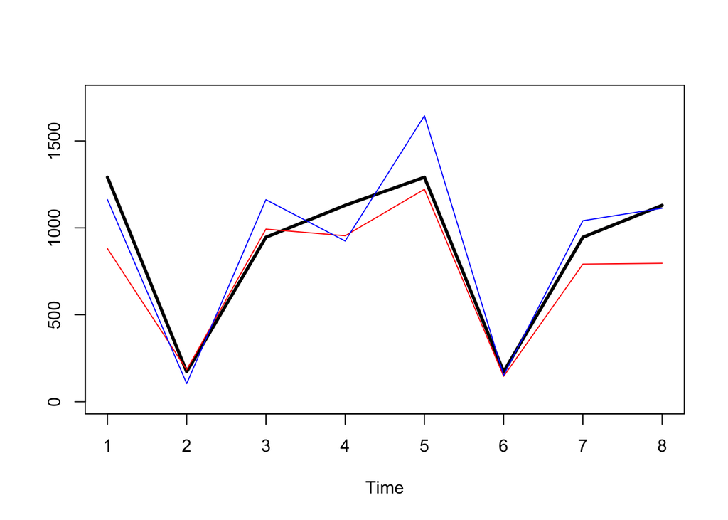

```r
ts.plot(Precipitation[,-c(1,3)], ylim=c(0,1750), col=c(1,2,4), lwd=c(3,1,1))
```

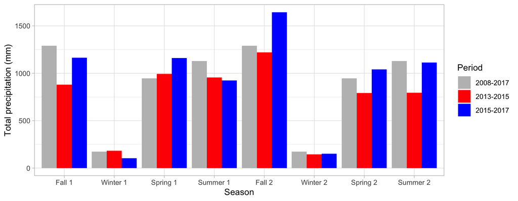

```r
library(dplyr)

Precipitation_long <- gather(Precipitation, key = "Period", value = "Precipitation",
        '2008-2017', '2013-2015', '2015-2017')
Precipitation_long$Season <- factor(Precipitation_long$Season, levels=paste(c("Fall", "Winter", "Spring", "Summer"), rep(1:2, each=4), sep=" "))

P.plot <- Precipitation_long %>%
  ggplot(aes(fill=Period, x = Season, y = Precipitation)) +
      geom_bar(position="dodge", stat = "identity") +
      scale_fill_manual(values=c("gray", "red", "blue")) +
      ylab("Total precipitation (mm)") +
      theme_light()

P.plot
```

### b) Quarterly mean temperature data

```r
tmp <- quarterly_data %>% group_by(quarter_noYear) %>% summarize(mean_temp=mean(mean_temp))
tmp <- tmp[c(4,1,2,3),]
Temperature <- data.frame(
  rep(tmp$quarter_noYear, 2),
  unlist(rep(tmp[,2], 2)),
  quarterly_data %>% filter(quarter > "2011 Q3", quarter < "2013 Q4") %>% select(mean_temp),
  quarterly_data %>% filter(quarter > "2013 Q3", quarter < "2015 Q4") %>% select(mean_temp),
  quarterly_data %>% filter(quarter > "2015 Q3", quarter < "2017 Q4") %>% select(mean_temp))

names(Temperature) <- c("Quarter", "2008-2020","2011-2013","2013-2015", "2015-2017")
Temperature$Season <- paste(c("Fall", "Winter", "Spring", "Summer"), rep(1:2, each=4), sep=" ")
```

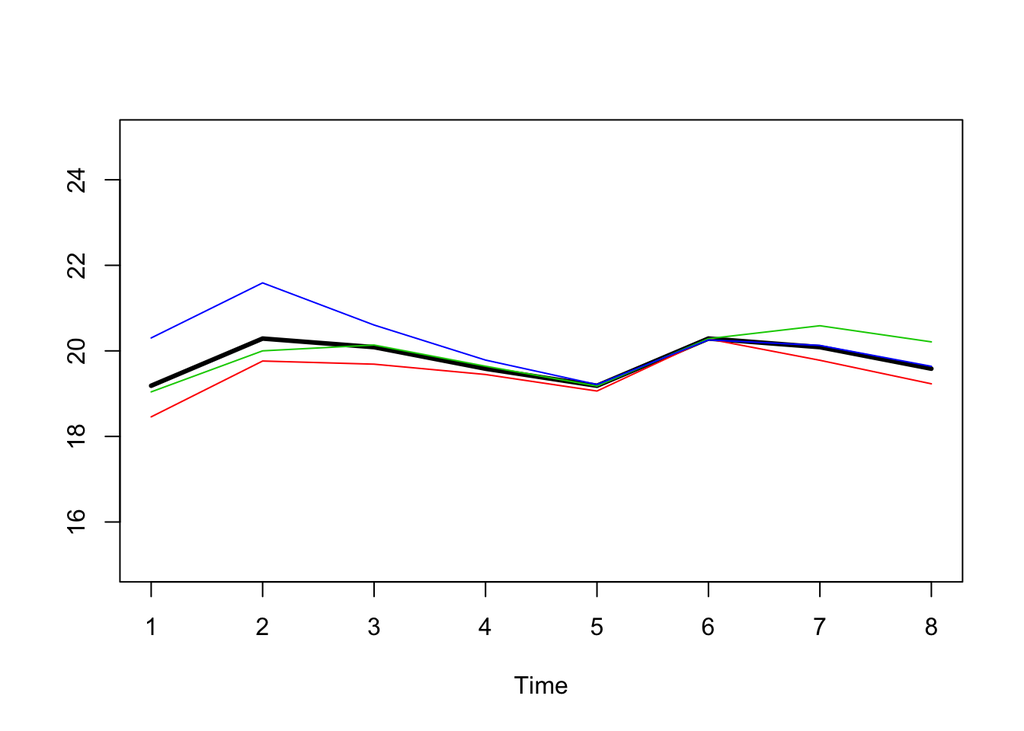

```r
ts.plot(Temperature[,-1], ylim=c(15,25), col=c(1:4), lwd=c(3,1,1,1))
```

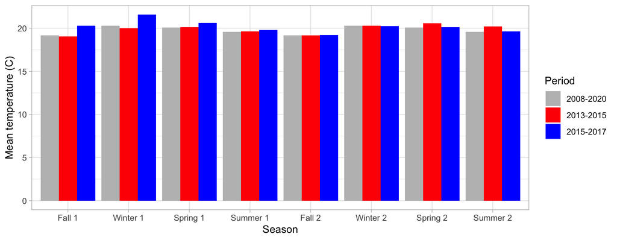

```r
library(dplyr)

Temperature_long <- gather(Temperature, key = "Period", value = "Temperature",
        '2008-2020', '2013-2015', '2015-2017')
Temperature_long$Season <- factor(Temperature_long$Season, levels=paste(c("Fall", "Winter", "Spring", "Summer"), rep(1:2, each=4), sep=" "))

T.plot <- Temperature_long %>%
  ggplot(aes(fill=Period, x = Season, y = Temperature)) +
      geom_bar(position="dodge", stat = "identity") +
      scale_fill_manual(values=c("gray", "red", "blue")) +
      ylab("Mean temperature (C)") +
      theme_light()

T.plot
```

### c) Relative to reference period

- Oct 2008 - Sept 2017 for precipitation
- Oct 2008 - Sept 2020 for temperature

```r
Relative <- data.frame(Season=c(Temperature$Season, "Total"),
                  P_2013_2015=c(Precipitation[,4]/Precipitation[,2],
                                sum(Precipitation[,4]) / sum(Precipitation[,2])),
                  P_2015_2017=c(Precipitation[,5]/Precipitation[,2],
                                sum(Precipitation[,5]) / sum(Precipitation[,2])),
                  T_2013_2015=c(Temperature[,4]/Temperature[,2],
                                mean(Temperature[,4]) / mean(Temperature[,2])),
                  T_2015_2017=c(Temperature[,5]/Temperature[,2],
                                mean(Temperature[,5]) / mean(Temperature[,2])))


names(Relative) <- c("Season", "Prec (2013-2015)", "Prec (2015-2017)", "Temp (2013-2015)", "Temp (2015-2017)")

for(i in 2:5) {Relative[,i] = round(Relative[,i],3)}

Relative
```

```
##     Season Prec (2013-2015) Prec (2015-2017) Temp (2013-2015) Temp (2015-2017)
## 1   Fall 1            0.682            0.900            0.993            1.058
## 2 Winter 1            1.069            0.604            0.986            1.064
## 3 Spring 1            1.049            1.228            1.002            1.026
## 4 Summer 1            0.845            0.818            1.003            1.010
## 5   Fall 2            0.946            1.274            1.000            1.001
## 6 Winter 2            0.848            0.882            1.000            0.998
## 7 Spring 2            0.837            1.101            1.025            1.002
## 8 Summer 2            0.705            0.985            1.032            1.003
## 9    Total            0.843            1.032            1.005            1.020
```

### d) Export table and figures

Export table with relative values

```r
write.table(Relative, "Relative.txt", sep="\t", row.names=FALSE)
```

Export barcharts

```r
pdf(paste0(here::here(), "/Temperature.pdf"), width=8, height=4)
T.plot
dev.off()
```

```r
pdf(paste0(here::here(), "/Precipitation.pdf"), width=8, height=4)
P.plot
dev.off()
```